# FML assignment univerasl bank

Bhuvaneshwar reddy kosna

2023-10-22

# PROBLEM STATEMENT

Universal Bank is a young bank that is fast expanding in terms of overall client acquisition. The majority of these clients are liability customers (depositors) with varied levels of relationship with the bank. The bank’s customer base of asset clients (borrowers) is fairly modest, and the bank is interested in swiftly increasing this base in additional loan activity. It is particularly interested in investigating methods of converting its liability consumers to personal loan customers. Last year, the bank executed a campaign for liability customers that had a solid conversion rate of more over 9% success. This has pushed the retail marketing department to create smarter campaigns with better target marketing. The purpose is to use k-NN to forecast if a new customer will accept a loan offer. This will serve as the foundation for the creation of a new campaign. Data about 5000 clients can be found in the file UniversalBank.csv. Customer demographic information (age, income, etc.), the customer’s relationship with the bank (mortgage, securities account, etc.), and the customer reaction to the most recent personal loan campaign (Personal Loan) are all included in the data. Only 480 (= 9.6%) of the 5000 consumers accepted the personal loan given in the previous campaign.

# SOLUTION

```r
#Read the csv file
Givendata <- read.csv("C:/Users/bhuva/Desktop/FML assignment-1/UniversalBank.csv")
#Summary of the data
summary(Givendata)
```

```
##        ID            Age          Experience       Income          ZIP.Code
##  Min.   :   1   Min.   :23.00   Min.   :-3.0   Min.   :  8.00   Min.   : 9307
##  1st Qu.:1251   1st Qu.:35.00   1st Qu.:10.0   1st Qu.: 39.00   1st Qu.:91911
##  Median :2500   Median :45.00   Median :20.0   Median : 64.00   Median :93437
##  Mean   :2500   Mean   :45.34   Mean   :20.1   Mean   : 73.77   Mean   :93153
##  3rd Qu.:3750   3rd Qu.:55.00   3rd Qu.:30.0   3rd Qu.: 98.00   3rd Qu.:94608
##  Max.   :5000   Max.   :67.00   Max.   :43.0   Max.   :224.00   Max.   :96651
##      Family          CCAvg          Education        Mortgage
##  Min.   :1.000   Min.   : 0.000   Min.   :1.000   Min.   :  0.0
##  1st Qu.:1.000   1st Qu.: 0.700   1st Qu.:1.000   1st Qu.:  0.0
##  Median :2.000   Median : 1.500   Median :2.000   Median :  0.0
##  Mean   :2.396   Mean   : 1.938   Mean   :1.881   Mean   : 56.5
##  3rd Qu.:3.000   3rd Qu.: 2.500   3rd Qu.:3.000   3rd Qu.:101.0
##  Max.   :4.000   Max.   :10.000   Max.   :3.000   Max.   :635.0
##  Personal.Loan   Securities.Account   CD.Account         Online
##  Min.   :0.000   Min.   :0.0000     Min.   :0.0000   Min.   :0.0000
##  1st Qu.:0.000   1st Qu.:0.0000     1st Qu.:0.0000   1st Qu.:0.0000
##  Median :0.000   Median :0.0000     Median :0.0000   Median :1.0000
##  Mean   :0.096   Mean   :0.1044     Mean   :0.0604   Mean   :0.5968
##  3rd Qu.:0.000   3rd Qu.:0.0000     3rd Qu.:0.0000   3rd Qu.:1.0000
##  Max.   :1.000   Max.   :1.0000     Max.   :1.0000   Max.   :1.0000
##    CreditCard
##  Min.   :0.000
##  1st Qu.:0.000
##  Median :0.000
##  Mean   :0.294
##  3rd Qu.:1.000
##  Max.   :1.000
```

```r
#Structure of the data
str(Givendata)
```

```
## 'data.frame':    5000 obs. of  14 variables:
##  $ ID                : int  1 2 3 4 5 6 7 8 9 10 ...
##  $ Age               : int  25 45 39 35 35 37 53 50 35 34 ...
##  $ Experience        : int  1 19 15 9 8 13 27 24 10 9 ...
##  $ Income            : int  49 34 11 100 45 29 72 22 81 180 ...
##  $ ZIP.Code          : int  91107 90089 94720 94112 91330 92121 91711 93943 90089 93023 ...
##  $ Family            : int  4 3 1 1 4 4 2 1 3 1 ...
##  $ CCAvg             : num  1.6 1.5 1 2.7 1 0.4 1.5 0.3 0.6 8.9 ...
##  $ Education         : int  1 1 1 2 2 2 2 3 2 3 ...
##  $ Mortgage          : int  0 0 0 0 0 155 0 0 104 0 ...
##  $ Personal.Loan     : int  0 0 0 0 0 0 0 0 0 1 ...
##  $ Securities.Account: int  1 1 0 0 0 0 0 0 0 0 ...
##  $ CD.Account        : int  0 0 0 0 0 0 0 0 0 0 ...
##  $ Online            : int  0 0 0 0 0 1 1 0 1 0 ...
##  $ CreditCard        : int  0 0 0 0 1 0 0 1 0 0 ...
```

```r
#Transpose of the data frame
t(t(names(Givendata)))
```

```
##       [,1]
##  [1,] "ID"
##  [2,] "Age"
##  [3,] "Experience"
##  [4,] "Income"
##  [5,] "ZIP.Code"
##  [6,] "Family"
##  [7,] "CCAvg"
##  [8,] "Education"
##  [9,] "Mortgage"
## [10,] "Personal.Loan"
## [11,] "Securities.Account"
## [12,] "CD.Account"
## [13,] "Online"
## [14,] "CreditCard"
```

```r
# Loading all the required libraries
library(caret)
library(class)
library(e1071)
library(knitr)

# Drop ID and ZIP code from the dataset
Givendata <- Givendata[,-c(1,5)]

# Transform categorical variables into dummy variables

# Converting Education to a factor
Givendata$Education <- as.factor(Givendata$Education)

# Now, convert Education to Dummy Variables
groups <- dummyVars(~., data = Givendata) # This creates the dummy groups

universal_m.df <- as.data.frame(predict(groups,Givendata))


# Split the data to 60% training and 40 % Validation

set.seed(1)
train.index <- sample(row.names(universal_m.df),0.6*dim(universal_m.df)[1])
valid.index <- setdiff(row.names(universal_m.df), train.index)
train.df <- universal_m.df[train.index,]
print(train.df)
```

[output not shown]

[output cut: 5987 more lines]

```r
valid.df <- universal_m.df[valid.index,]
t(t(names(train.df)))
```

```
##       [,1]
##  [1,] "Age"
##  [2,] "Experience"
##  [3,] "Income"
##  [4,] "Family"
##  [5,] "CCAvg"
##  [6,] "Education.1"
##  [7,] "Education.2"
##  [8,] "Education.3"
##  [9,] "Mortgage"
## [10,] "Personal.Loan"
## [11,] "Securities.Account"
## [12,] "CD.Account"
## [13,] "Online"
## [14,] "CreditCard"
```

```r
# Normalize the data

train.norm.df <- train.df[,-10] # Personal Income is the 10th variable.
valid.norm.df <- valid.df[,-10]

norm.values <- preProcess(train.df[, -10], method=c("center", "scale"))
train.norm.df <- predict(norm.values, train.df[, -10])
valid.norm.df <- predict(norm.values, valid.df[, -10])
```

### Question - 1

Age = 40, Experience = 10, Income = 84, Family = 2, CCAvg = 2, Education_1 = 0, Education_2 = 1, Education_3 = 0, Mortgage = 0, Securities Account = 0, CD Account = 0, Online = 1, and Credit Card = 1. Perform a k-NN classification with all predictors except ID and ZIP code using k = 1. Remember to transform categorical predictors with more than two categories into dummy variables first. Specify the success class as 1 (loan acceptance), and use the default cutoff value of 0.5. How would this customer be classified?

```r
# We have already converted all categorical variables to dummy variables
# Classify the given customer
given_customer <- data.frame(
  Age = 40,
  Experience = 10,
  Income = 84,
  Family = 2,
  CCAvg = 2,
  Education.1 = 0,
  Education.2 = 1,
  Education.3 = 0,
  Mortgage = 0,
  Securities.Account = 0,
  CD.Account = 0,
  Online = 1,
  CreditCard = 1)

# Normalize the given customer data
#given.cust.norm <- given_customer
given.cust.norm <- predict(norm.values, given_customer)
#  Classify the customer using k-NN with k=1
knn_result <- class::knn(train = train.norm.df,test = given.cust.norm, cl = train.df$Personal.Loan, k=1)
knn_result
```

```
## [1] 0
## Levels: 0 1
```

#### Determine how the customer would be classified

```r
if (knn_result == 1) {
  cat("The customer is classified as likely to accept the loan offer (Loan Acceptance = 1).\n")
} else {
  cat("The customer is classified as unlikely to accept the loan offer (Loan Acceptance = 0).\n")
}
```

```
## The customer is classified as unlikely to accept the loan offer (Loan Acceptance = 0).
```

### Question - 2

What is a choice of k that balances between overfitting and ignoring the predictor information?

#### The best choice of k which also balances the model from overfitting is k = 3

```r
# Calculate the accuracy for each value of k
# Set the range of k values to consider
accuracy.df <- data.frame(k = seq(1, 20, 1), overallaccuracy = rep(0, 20))
for(i in 1:20)
{knn.pred <- class::knn(train = train.norm.df,
                         test = valid.norm.df,
                         cl = train.df$Personal.Loan, k = i)
accuracy.df[i, 2] <- confusionMatrix(knn.pred,as.factor(valid.df$Personal.Loan),positive = "1")$overall[1]
}
which(accuracy.df[,2] == max(accuracy.df[,2]))
```

```
## [1] 3
```

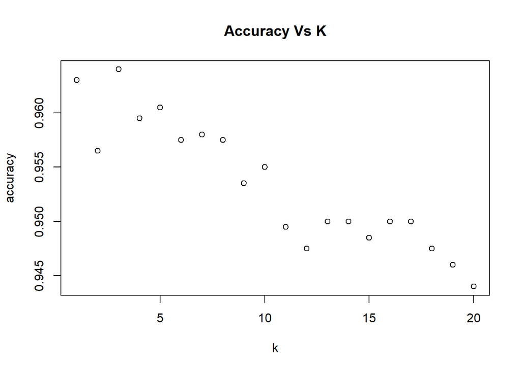

```r
plot(accuracy.df$k,accuracy.df$overallaccuracy, main = "Accuracy Vs K", xlab = "k", ylab = "accuracy")
```

### Question - 3

Show the confusion matrix for the validation data that results from using the best k.

#### Confusion Matrix using best K=3

```r
knn_result <- class::knn(train = train.norm.df,
                         test = valid.norm.df,
                         cl = train.df$Personal.Loan, k = 3)

confusionMatrix(knn_result,as.factor(valid.df$Personal.Loan))
```

```
## Confusion Matrix and Statistics
##
##           Reference
## Prediction    0    1
##          0 1786   63
##          1    9  142
##
##                Accuracy : 0.964
##                  95% CI : (0.9549, 0.9717)
##     No Information Rate : 0.8975
##     P-Value [Acc > NIR] : < 2.2e-16
##
##                   Kappa : 0.7785
##
##  Mcnemar's Test P-Value : 4.208e-10
##
##             Sensitivity : 0.9950
##             Specificity : 0.6927
##          Pos Pred Value : 0.9659
##          Neg Pred Value : 0.9404
##              Prevalence : 0.8975
##          Detection Rate : 0.8930
##    Detection Prevalence : 0.9245
##       Balanced Accuracy : 0.8438
##
##        'Positive' Class : 0
##
```

### Question - 4

Consider the following customer: Age = 40, Experience = 10, Income = 84, Family = 2, CCAvg = 2, Education_1 = 0, Education_2 = 1, Education_3 = 0, Mortgage = 0, Securities Account = 0, CD Account = 0, Online = 1 and Credit Card = 1. Classify the customer using the best k.

```r
given_customer2<-data.frame(
  Age = 40,
  Experience = 10,
  Income = 84,
  family =2,
  CCAvg = 2,
  Education_1 = 0,
  Education_2 = 1,
  Education_3 = 0,
  Mortgage = 0,
  Securities.Account = 0,
  CDAccount = 0,
  Online = 1,
  CreditCard = 1)

knn_result <- class::knn(train = train.norm.df,
                       test = given.cust.norm,
                       cl = train.df$Personal.Loan, k = 3)
knn_result
```

```
## [1] 0
## Levels: 0 1
```

#### Print the predicted customer class

```r
if (knn_result == 1) {
  cat("The customer is classified as likely to accept the loan offer (Loan Acceptance = 1).\n")
} else {
  cat("The customer is classified as unlikely to accept the loan offer (Loan Acceptance = 0).\n")
}
```

```
## The customer is classified as unlikely to accept the loan offer (Loan Acceptance = 0).
```

### Question - 5

Repartition the data, this time into training, validation, and test sets (50% : 30% : 20%). Apply the k-NN method with the k chosen above. Compare the confusion matrix of the test set with that of the training and validation sets. Comment on the differences and their reason.

```r
# Split the data to 50% training and 30% Validation and 20% Testing
set.seed(1)
Train_Index1 <- sample(row.names(universal_m.df), 0.5*dim(universal_m.df)[1])
Val_Index1 <- sample(setdiff(row.names(universal_m.df),Train_Index1),0.3*dim(universal_m.df)[1])
Test_Index1 <-setdiff(row.names(universal_m.df),union(Train_Index1,Val_Index1))
Train_Data <- universal_m.df[Train_Index1,]
Validation_Data <- universal_m.df[Val_Index1,]
Test_Data <- universal_m.df[Test_Index1,]

# Normalize the data
train.norm.df1 <- Train_Data[,-10]
valid.norm.df1 <- Validation_Data[,-10]
Test.norm.df1  <-Test_Data[,-10]

norm.values1 <- preProcess(Train_Data[, -10], method=c("center", "scale"))
train.norm.df1 <- predict(norm.values1, Train_Data[,-10])
valid.norm.df1 <- predict(norm.values1, Validation_Data[,-10])
Test.norm.df1 <-predict(norm.values1,Test_Data[,-10])

# Predict using K-NN(k- Nearest neighbors)

validation_knn = class::knn(train = train.norm.df1,
                           test = valid.norm.df1,
                           cl = Train_Data$Personal.Loan,
                           k = 3)

test_knn = class::knn(train = train.norm.df1,
                     test = Test.norm.df1,
                     cl = Train_Data$Personal.Loan,
                     k = 3)

Train_knn = class::knn(train = train.norm.df1,
                     test = train.norm.df1,
                     cl = Train_Data$Personal.Loan,
                     k = 3)
```

### Validation confusion Matrix

```r
validation_confusion_matrix = confusionMatrix(validation_knn,
                                               as.factor(Validation_Data$Personal.Loan), positive = "1")

validation_confusion_matrix
```

```
## Confusion Matrix and Statistics
##
##           Reference
## Prediction    0    1
##          0 1358   42
##          1    6   94
##
##                Accuracy : 0.968
##                  95% CI : (0.9578, 0.9763)
##     No Information Rate : 0.9093
##     P-Value [Acc > NIR] : < 2.2e-16
##
##                   Kappa : 0.7797
##
##  Mcnemar's Test P-Value : 4.376e-07
##
##             Sensitivity : 0.69118
##             Specificity : 0.99560
##          Pos Pred Value : 0.94000
##          Neg Pred Value : 0.97000
##              Prevalence : 0.09067
##          Detection Rate : 0.06267
##    Detection Prevalence : 0.06667
##       Balanced Accuracy : 0.84339
##
##        'Positive' Class : 1
##
```

### Test confusion Matrix

```r
test_confusion_matrix = confusionMatrix(test_knn,
                                         as.factor(Test_Data$Personal.Loan),  positive = "1")


test_confusion_matrix
```

```
## Confusion Matrix and Statistics
##
##           Reference
## Prediction   0   1
##          0 884  35
##          1   4  77
##
##                Accuracy : 0.961
##                  95% CI : (0.9471, 0.9721)
##     No Information Rate : 0.888
##     P-Value [Acc > NIR] : < 2.2e-16
##
##                   Kappa : 0.777
##
##  Mcnemar's Test P-Value : 1.556e-06
##
##             Sensitivity : 0.6875
##             Specificity : 0.9955
##          Pos Pred Value : 0.9506
##          Neg Pred Value : 0.9619
##              Prevalence : 0.1120
##          Detection Rate : 0.0770
##    Detection Prevalence : 0.0810
##       Balanced Accuracy : 0.8415
##
##        'Positive' Class : 1
##
```

### Train confusion Matrix

```r
Training_confusion_matrix = confusionMatrix(Train_knn,
                                               as.factor(Train_Data$Personal.Loan),  positive = "1")

Training_confusion_matrix
```

```
## Confusion Matrix and Statistics
##
##           Reference
## Prediction    0    1
##          0 2263   54
##          1    5  178
##
##                Accuracy : 0.9764
##                  95% CI : (0.9697, 0.982)
##     No Information Rate : 0.9072
##     P-Value [Acc > NIR] : < 2.2e-16
##
##                   Kappa : 0.8452
##
##  Mcnemar's Test P-Value : 4.129e-10
##
##             Sensitivity : 0.7672
##             Specificity : 0.9978
##          Pos Pred Value : 0.9727
##          Neg Pred Value : 0.9767
##              Prevalence : 0.0928
##          Detection Rate : 0.0712
##    Detection Prevalence : 0.0732
##       Balanced Accuracy : 0.8825
##
##        'Positive' Class : 1
##
```

### Summary of the data and potential reasons for the differences:

Training Set Confusion Matrix: This matrix is based on the data used to train the model, hence it may have high accuracy, potentially close to 100%, especially with k-NN where k = 3. Because the model has seen this data previously and may have overfitted it, high true positives and true negatives can be expected.

Validation Set Confusion Matrix: This matrix displays the model’s performance on new data that it hasn’t seen before.Because the model may not generalize precisely to new consumers, accuracy may be slightly lower than on the training set.Some false positives and false negatives may be observed, indicating that the model may make errors on unknown data.This matrix gives a more accurate prediction of how well the model will perform in practice.

Test Set Confusion Matrix:The test set confusion matrix is the most important evaluation because it provides fully unique facts, similar to real-world customers.Depending on the dataset’s properties and the model’s generalization ability, the accuracy may be similar to or somewhat poorer than the validation set.Differences between the test and validation/training sets can be attributed to differences in data distribution, noise, and the model’s adaptability to varied patterns.

### Potential Reasons for Differences:

Differences in data sets: The content and distribution of data in various sets can have a significant impact on how well a model works. For example, one data collection may be more uneven than another, making it more difficult to foresee uncommon events.

Overfitting: Overfitting may have happened if the training set outperforms the validation and test sets. The model may not generalize well since it was trained too closely to the training data.

Data Quality: Variations in data quality, distribution, or the presence of outliers between sets can all have an impact on performance.

Sample Size: Performance metrics may be more varied if the validation and test sets comprise fewer samples.

Unpredictability: Variations may also occur as a result of the unpredictability of the data segmentation and the specific samples chosen for each set.

Tuning of hyperparameters: The value of k in k-NN or other model-specific parameters, for example, may have an effect on model performance.